# Individual Portion: Streaming Data

STT2860 F22 Project 03

Taylor Lautz, Nichole Johnson, Lauren Edelman

Tuesday, December 06, 2022 @ 04:26 PM

## Setup

### Packages Used

```r
library(tidyverse)
library(waffle)
```

### Background of the Data

The datasets were downloaded from [Disney+ Movies and TV Shows | Kaggle](https://www.kaggle.com/datasets/shivamb/disney-movies-and-tv-shows) and [TV shows on Netflix, Prime Video, Hulu and Disney+ | Kaggle](https://www.kaggle.com/datasets/ruchi798/tv-shows-on-netflix-prime-video-hulu-and-disney). You can read about them there, including variable definitions, sources, when they were created, and other information. Load the two datasets and use `glimpse()` to explore their structures.

#### Disney+ Dataset

```r
 disneypluscontent <- readRDS("data/disneypluscontent.rds")
head(disneypluscontent)
```

```
# A tibble: 6 × 13
  show_id type    title     direc…¹ cast  country date_…² relea…³ rating durat…⁴
  <chr>   <chr>   <chr>     <chr>   <chr> <chr>   <chr>     <dbl> <fct>  <chr>
1 s1      Movie   Duck the… Alonso… Chri… <NA>    26-Nov…    2016 TV-G   23
2 s2      Movie   Ernest S… John C… Jim … <NA>    26-Nov…    1988 PG     91
3 s3      Movie   Ice Age:… Karen … Raym… United… 26-Nov…    2011 TV-G   23
4 s4      Movie   The Quee… Hamish… Darr… <NA>    26-Nov…    2021 TV-PG  41
5 s6      Movie   Becoming… Liz Ga… Jacq… United… 24-Nov…    2021 PG-13  94
6 s7      TV Show Hawkeye   <NA>    Jere… <NA>    24-Nov…    2021 TV-14  1
# … with 3 more variables: duration_unit <chr>, listed_in <chr>,
#   description <chr>, and abbreviated variable names ¹director, ²date_added,
#   ³release_year, ⁴duration
```

#### Streaming Dataset

```r
streamingcontent <- readRDS("data/streamingcontent.rds")
```

## Analyses

### Create the Analysis Datasets

#### Disney+ Dataset

Use `select()` to delete the variables `director`, `cast`, `country`, `listed in`, and `description` from the dataset.

```r
disneypluscontent1 <- select(disneypluscontent, -c("director", "cast", "country", "listed_in", "description"))
```

#### Streaming Dataset

I used a function called `pivot_longer()` on the downloaded data to change the shape of the dataset. You will need to do additional necessary editing on the dataset before you analyze it.

- Use `filter()` to remove any row where `YesNo` is `0` (a `0` means it is *not* on the service).
- Use the `separate()` function to split `IMDb`. Separate the show rating from the max rating of `10`.
- Use the `separate()` function to split `RottenTomatoes`. Separate the show rating from the max rating of `100`.
- Use `mutate()` to convert the shows’ IMDb and Rotten Tomatoes ratings into numerical variables instead of categorical.

```r
streamingcontent1 <- streamingcontent %>%
    filter(YesNo != 0) %>%
separate(IMDb, c("IMDb_rating", "IMDb_max_rating"),"/") %>%
separate(RottenTomatoes, c("RT_rating", "RT_max_rating"), "/") %>%
mutate(IMDb_rating = as.numeric(IMDb_rating), IMDb_max_rating = as.numeric(IMDb_max_rating), RT_rating = as.numeric(RT_rating), RT_max_rating = as.numeric(RT_max_rating))

glimpse(streamingcontent1)
```

```
Rows: 5,774
Columns: 10
$ ID              <dbl> 1, 2, 3, 3, 4, 5, 6, 6, 7, 8, 9, 10, 11, 12, 12, 12, 1…
$ Title           <chr> "Breaking Bad", "Stranger Things", "Attack on Titan", …
$ Year            <dbl> 2008, 2016, 2013, 2013, 2015, 2017, 2005, 2005, 2013, …
$ Age             <fct> 18+, 16+, 18+, 18+, 18+, 16+, 7+, 7+, 18+, 18+, 18+, 1…
$ IMDb_rating     <dbl> 9.4, 8.7, 9.0, 9.0, 8.8, 8.8, 9.3, 9.3, 8.8, 8.2, 8.8,…
$ IMDb_max_rating <dbl> 10, 10, 10, 10, 10, 10, 10, 10, 10, 10, 10, 10, 10, 10…
$ RT_rating       <dbl> 100, 96, 95, 95, 94, 93, 93, 93, 93, 93, 92, 92, 90, 9…
$ RT_max_rating   <dbl> 100, 100, 100, 100, 100, 100, 100, 100, 100, 100, 100,…
$ Service         <chr> "Netflix", "Netflix", "Netflix", "Hulu", "Netflix", "N…
$ YesNo           <dbl> 1, 1, 1, 1, 1, 1, 1, 1, 1, 1, 1, 1, 1, 1, 1, 1, 1, 1, …
```

### Visualization 1: Release Year

**These plots use the Disney+ Dataset.**

A frequency polygon (`geom_freqpoly()`) is an alternative to a histogram. Rather than displaying bars, it connects the midpoints of a histogram’s bars with line segments. Create a frequency polygon for the year in which Disney+ content was released. Add an appropriate title and axis labels. Use other formatting as you choose to enhance effectiveness/appearance.

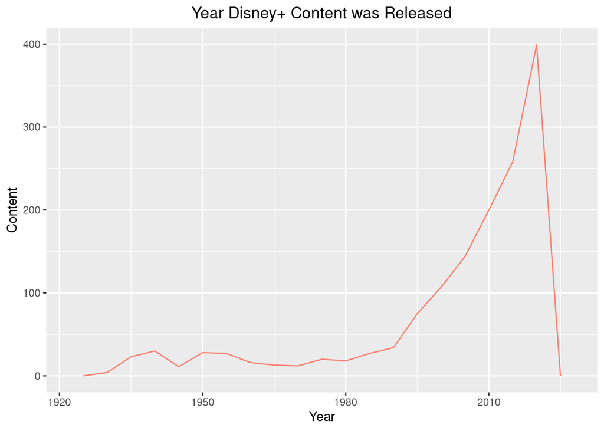

```r
ggplot(disneypluscontent1, aes(release_year)) +
    geom_freqpoly(binwidth = 5, color = "salmon") +
    labs(
    title = "Year Disney+ Content was Released",
    x = "Year",
    y = "Content"
  ) +
  theme(plot.title = element_text(hjust = 0.5))
```

Create a violin plot of `release_year` (x-axis) grouped by `type` of program (y-axis) for content on Disney+. Fill with a color of your choice. Add a boxplot inside the violin plot, as you did in one of the DataCamp exercises. Re-scale the x-axis so that tick marks appear at whole-decade intervals (e.g., 1980, 1990, 2000). Add an appropriate title and axis labels. Use other formatting as you choose to enhance effectiveness/appearance.

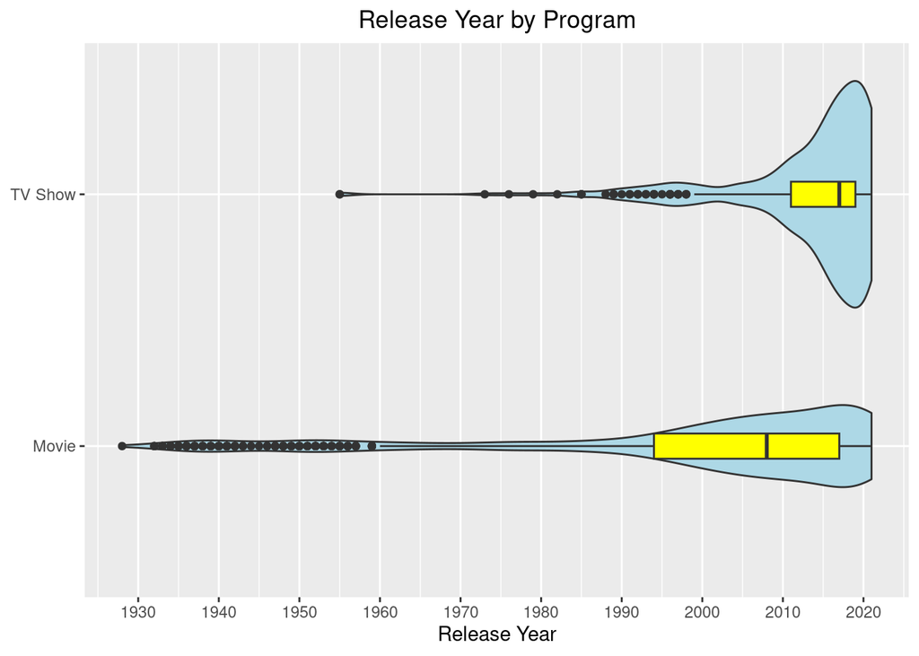

```r
ggplot(disneypluscontent1, aes(release_year, y = type)) +
    geom_violin(fill = "lightblue") +
    geom_boxplot(width = 0.1, fill = "yellow") +
    scale_x_continuous(breaks = seq(from = 1920, to = 2020, by = 10)) +
    labs(
    title = "Release Year by Program",
    x = "Release Year",
    y = "Program" +
    theme_linedraw()
    ) +
 theme(plot.title = element_text(hjust = 0.5))
```

### Visualization 2: Program Type

**This plot uses the Disney+ Dataset.**

Create a waffle plot (which you learned in DataCamp: [Visualization Best Practices in R](https://app.datacamp.com/learn/courses/visualization-best-practices-in-r)) to display the distribution of program `type` on Disney+.

- Give the plot the title “Streaming Content on Disney+”.
- Change the colors of the squares to something other than the defaults.
- Use an x-axis label to indicate roughly how many programs each square represents.

Hint: Use `round(100 * prop.table(table(DATASETNAME$VARIABLENAME)))` to create the “case_counts” data for the waffle plot. Swap out the capital letter placeholders in the instructions for the correct dataset name and variable name.

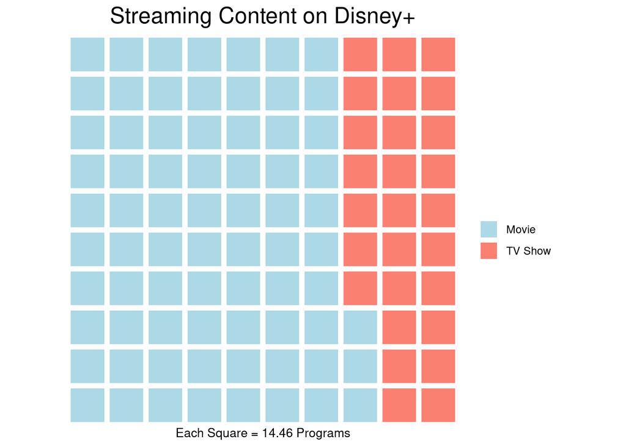

```r
case_counts <- round(100 * prop.table(table(disneypluscontent1$type)))

waffle(case_counts, xlab = "Each Square = 14.46 Programs", title = "Streaming Content on Disney+", colors = c("lightblue", "salmon")) +
theme(plot.title = element_text(hjust = 0.5))
```

### Visualization 3: Choose a Plot!

**This plot uses the Disney+ Dataset.**

Create one other plot of your choice from the Disney+ Dataset to explore a question of interest. You are welcome to perform additional manipulations on the data, if needed. Add an appropriate title and axis labels, as well as any other necessary formatting.

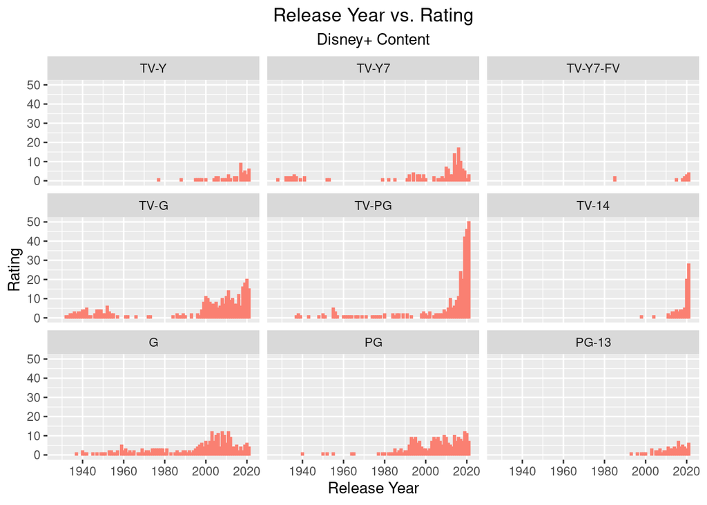

```r
ggplot(disneypluscontent1, aes(x = release_year)) +
  geom_bar(color = "salmon", fill = "salmon") +
    facet_wrap(.~ rating) +
    scale_x_continuous(breaks = seq(from = 1920, to = 2020, by = 20)) +
  labs(
    title = "Release Year vs. Rating",
    subtitle = "Disney+ Content",
    x = "Release Year",
    y = "Rating"
  ) +
  theme(plot.title = element_text(hjust = 0.5), plot.subtitle = element_text(hjust = 0.5))
```

### Visualization 4: Content Volume

**This plot uses the Streaming Dataset.**

Create a barplot to display how many shows are offered on each of the four streaming services. Choose appropriate colors, labels, themes, and/or and other types of formatting that you feel will enhance the meaning or visual appearance of the plot.

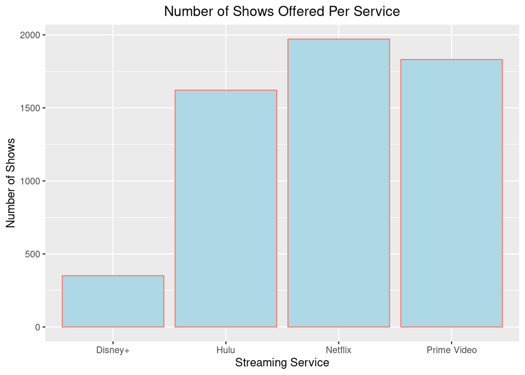

```r
ggplot(streamingcontent1, aes(x = Service)) +
  geom_bar(color = "salmon", fill = "lightblue") +
  labs(
    title = "Number of Shows Offered Per Service",
    x = "Streaming Service",
    y = "Number of Shows"
  ) +
theme(plot.title = element_text(hjust = 0.5))
```

### Visualization 5: Choose a Plot!

**This plot uses the Streaming Dataset.**

Create one other plot of your choice from the Streaming Dataset to explore a question of interest. You are welcome to perform additional manipulations on the data, if needed. Add an appropriate title and axis labels, as well as any other necessary formatting.

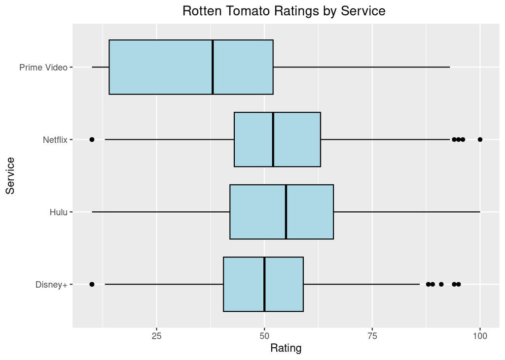

```r
ggplot(streamingcontent1, aes(x = RT_rating, y = Service)) +
  geom_boxplot(color = "black" , fill = "lightblue") +
  labs(
    title = "Rotten Tomato Ratings by Service ",
    x = "Rating",
    y = "Service"
  ) +
  theme(plot.title = element_text(hjust = 0.5))
```

## Questions

**Question 1:** Based on your plots, make five informational statements or comparisons regarding the Disney+ streaming service.

**Question 2:** What other data would you like to have, or which existing variables would you like to see transformed, if you were going to do further explorations or visualizations? Give at least two examples.

**ANSWER**

We would have liked to also had data on the money that Disney+ has made on their movies vs. their tv shows. If we were able to compare this we might could make a connection to why they have 1055 movies and only 390 tv shows on the platform. Another piece of data we would have liked to have had would have been the income of the different shows and movies prior to the platform exisiting, and their income now that the platform hosts them as well. This would give us an insight into how well Disney+ is doing as a platform.

**Question 3:** Explain the rationale behind the choices you made with regard to plot type, formatting, and so on, when you created Visualizations 3 and 5. Walk me through your process. What motivated your decisions?

**ANSWER** When it comes to the different plots that we made, we made choices in regards to the plot types that would most easily display the data we picked out. We edited the plots so that they would appear more ascetically pleasing to look at, (we centered the titles, added subtitles, added color to the plots, ect.) For visualization number 3 we went with a faceted plot that looked at the release years versus the ratings. We chose to make this a faceted plot so that we could look specifically at the ratings individually. For visualization number 5 we went with a boxplot. This plot displayed the ratings by service. From this plot we were able to conclude that of the four streaming platforms, Prime had the lowest ratings. ***